# Analysis of Hr indicators as predictor of employeers left

Giusti Elena,Sarah Wong,Zohaib Gulzar, Tatsuya Nagata.

# Human Resources Analytics

## Why are our best and most experienced employees leaving prematurely?

This is a dataset that includes 14999 observation of single employees  
Fields in the dataset include:

Employee satisfaction level  
Last evaluation  
Number of projects  
Average monthly hours  
Time spent at the company  
Whether they have had a work accident  
Whether they have had a promotion in the last 5 years  
Department  
Salary  
Whether the employee has left

## The objectives of the project are the followings

Which of those factors influence the employeers decison to left?  
Who will leave next?  
Is it possible to target with some specific strategy some department?

## The project is divided in the following step

Step 1) Analyse actual state of the company HR indicators - Clean the data - Describe the data  
Step 2) Analyse correlation and main factor definining HR indicators -Correlationa analysis -Factor reduction  
Step 3) Build a regression model to estimate who will be more likely to leave -Simple regression model -Randomtree model

## Step 1: Analyse actual state of the company HR indicator

Looking at data we can make the following assumptions related the nature of the 10 variables

satisfaction_level: A numeric indictor, presumably filled out by the employee.  
last_evaluation: A numeric indicator, presumably filled in by the employeeâ€™s manager.  
number_project: A integer - perhaps the number of projects the employee has worked on.  
average_monthly_hours: The number of hours they work in the month time_spend_company: An integer value, perhaps years of service.  
Work_accident: Looks like a boolean value, probably whether(1) or not(0) they had an accident.  
left: Looks like a boolean value, leave (1), not leave(0) promoted_last_5years: Looks like a boolean value, promoted(1), not promoted(0)  
sales: Is a categorical variable assessing the department (sales,technical…)  
salary: Looks like a 3-level salary score (low, medium, high)

### Data quality report

```
##  satisfaction_level last_evaluation  number_project  average_montly_hours
##  Min.   :0.0900     Min.   :0.3600   Min.   :2.000   Min.   : 96.0
##  1st Qu.:0.4400     1st Qu.:0.5600   1st Qu.:3.000   1st Qu.:156.0
##  Median :0.6400     Median :0.7200   Median :4.000   Median :200.0
##  Mean   :0.6128     Mean   :0.7161   Mean   :3.803   Mean   :201.1
##  3rd Qu.:0.8200     3rd Qu.:0.8700   3rd Qu.:5.000   3rd Qu.:245.0
##  Max.   :1.0000     Max.   :1.0000   Max.   :7.000   Max.   :310.0
##
##  time_spend_company Work_accident         left
##  Min.   : 2.000     Min.   :0.0000   Min.   :0.0000
##  1st Qu.: 3.000     1st Qu.:0.0000   1st Qu.:0.0000
##  Median : 3.000     Median :0.0000   Median :0.0000
##  Mean   : 3.498     Mean   :0.1446   Mean   :0.2381
##  3rd Qu.: 4.000     3rd Qu.:0.0000   3rd Qu.:0.0000
##  Max.   :10.000     Max.   :1.0000   Max.   :1.0000
##
##  promotion_last_5years         sales         salary
##  Min.   :0.00000       sales      :4140   high  :1237
##  1st Qu.:0.00000       technical  :2720   low   :7316
##  Median :0.00000       support    :2229   medium:6446
##  Mean   :0.02127       IT         :1227
##  3rd Qu.:0.00000       product_mng: 902
##  Max.   :1.00000       marketing  : 858
##                        (Other)    :2923
```

From basic statistical analysis we see that the overall satisfaction of the company is really low around 63% and that approximately 24% of the employees left. This brings us to the following step we would like therefore to understand bettwe who are the employees that are leaving

## Step 2: visualisations

We will start our analysis looking more deeply to a set of all emplyees

### First visualisations of the employees who left

We will start our analysis looking more deeply to a subset composed of all emplyees who left

In the total of 15 000 employees that compose our database, here are the people that have left:

```
## [1] 3571
```

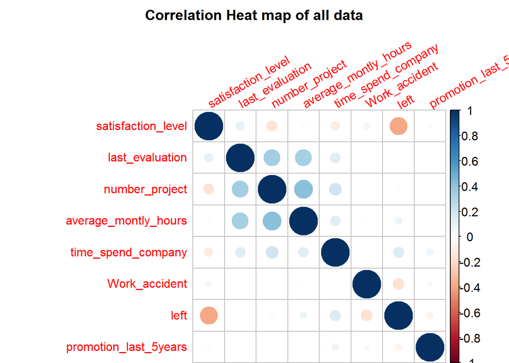

[figure not shown]

## Step 3: Analysing Who is leaving?

Number of people valuable to the company leaving. The screening criterea is that the employees have worked for company for more than 3 years and have good last evaluation results >0.65

```
## [1] 3562
```

[figure not shown]

Let’s create a data frame with only the people that have left the company, so we can visualise what is the distribution of each features:

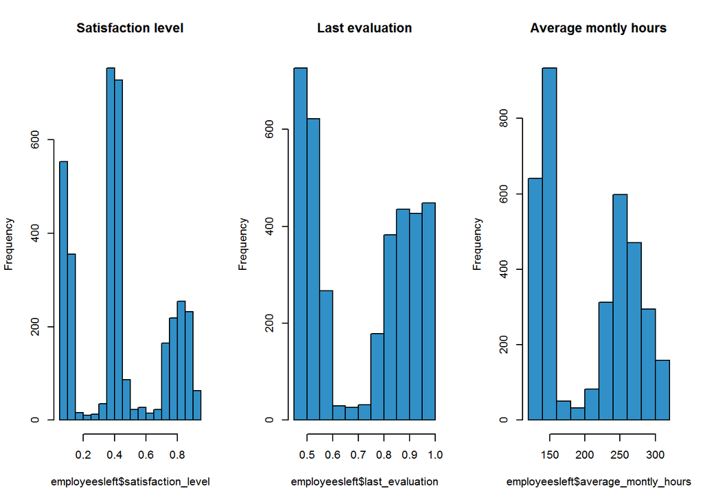

We can see why we don’t want to retain everybody. Some people don’t work well as we can see from their evaluation, but clearly there are also many good workers that leave.

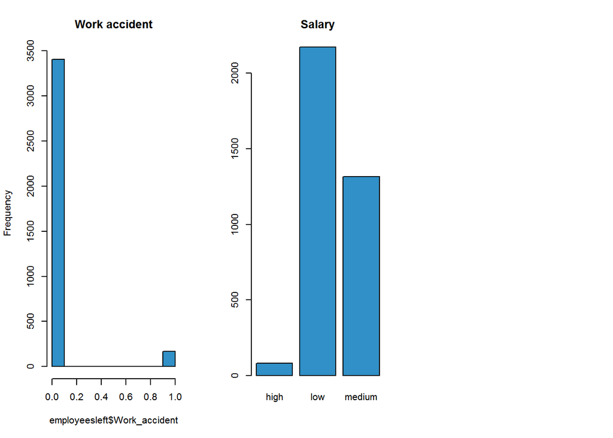

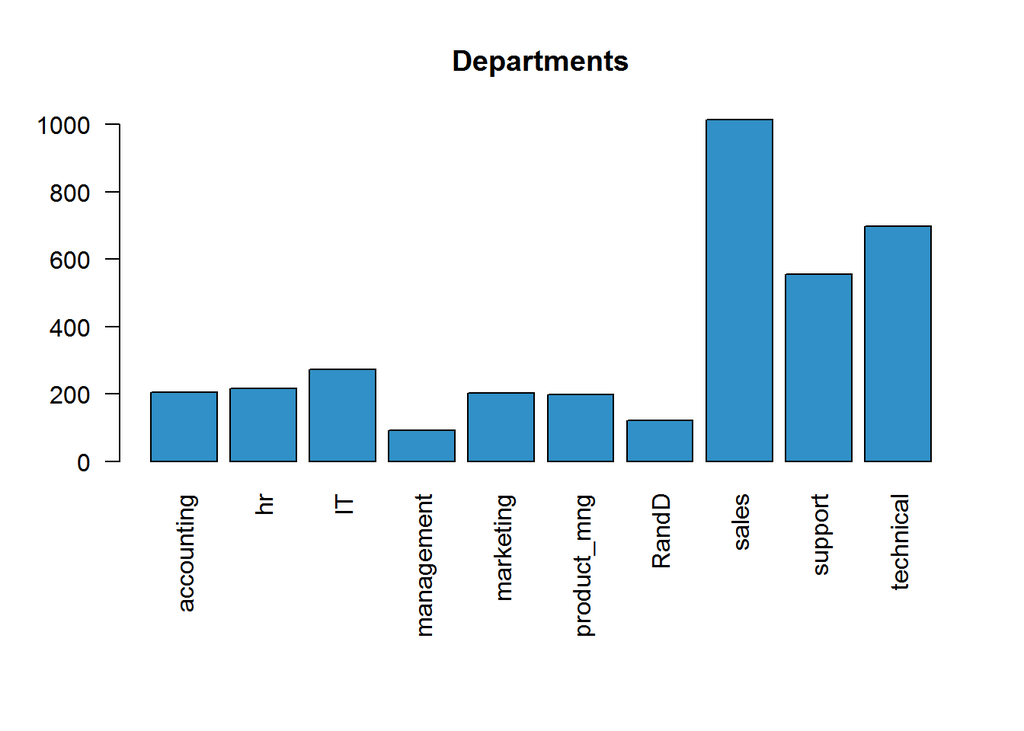

From the previous histograms we can colcude that not only employers with low satisfaction level and bad evaluation are leaving.

Looking at data it seems that none of the distribution is normal but show strong polarization:

## Step 4: Principal Component Analysis

To perform correlation we need first of all to normalize those data that are not metric and to drop the value that we want to predict (left) from the ananlysis

```
## [1] "satisfaction_level"    "last_evaluation"       "number_project"
## [4] "average_montly_hours"  "time_spend_company"    "Work_accident"
## [7] "promotion_last_5years" "sales"                 "salary"
```

```
## [1] "satisfaction_level"    "last_evaluation"       "number_project"
## [4] "average_montly_hours"  "time_spend_company"    "Work_accident"
## [7] "promotion_last_5years" "sales"                 "salary"
```

After having done this adjustments we can now confirm that data are metric. However we need to scale the data to have a more homogeneus dataset

|  | min | 25 percent | median | mean | 75 percent | max | std |
| --- | --- | --- | --- | --- | --- | --- | --- |
| satisfaction_level | 0.09 | 0.44 | 0.64 | 0.61 | 0.82 | 1 | 0.25 |
| last_evaluation | 0.36 | 0.56 | 0.72 | 0.72 | 0.87 | 1 | 0.17 |
| number_project | 2.00 | 3.00 | 4.00 | 3.80 | 5.00 | 7 | 1.23 |
| average_montly_hours | 96.00 | 156.00 | 200.00 | 201.05 | 245.00 | 310 | 49.94 |
| time_spend_company | 2.00 | 3.00 | 3.00 | 3.50 | 4.00 | 10 | 1.46 |
| Work_accident | 0.00 | 0.00 | 0.00 | 0.14 | 0.00 | 1 | 0.35 |
| promotion_last_5years | 0.00 | 0.00 | 0.00 | 0.02 | 0.00 | 1 | 0.14 |
| sales | 1.00 | 5.00 | 8.00 | 6.94 | 9.00 | 10 | 2.75 |
| salary | 1.00 | 1.00 | 2.00 | 1.59 | 2.00 | 3 | 0.64 |

Notice now the summary statistics of the scaled dataset:

|  | min | 25 percent | median | mean | 75 percent | max | std |
| --- | --- | --- | --- | --- | --- | --- | --- |
| satisfaction_level | -2.10 | -0.70 | 0.11 | 0 | 0.83 | 1.56 | 1 |
| last_evaluation | -2.08 | -0.91 | 0.02 | 0 | 0.90 | 1.66 | 1 |
| number_project | -1.46 | -0.65 | 0.16 | 0 | 0.97 | 2.59 | 1 |
| average_montly_hours | -2.10 | -0.90 | -0.02 | 0 | 0.88 | 2.18 | 1 |
| time_spend_company | -1.03 | -0.34 | -0.34 | 0 | 0.34 | 4.45 | 1 |
| Work_accident | -0.41 | -0.41 | -0.41 | 0 | -0.41 | 2.43 | 1 |
| promotion_last_5years | -0.15 | -0.15 | -0.15 | 0 | -0.15 | 6.78 | 1 |
| sales | -2.16 | -0.70 | 0.39 | 0 | 0.75 | 1.12 | 1 |
| salary | -0.93 | -0.93 | 0.64 | 0 | 0.64 | 2.21 | 1 |

We can therefore look to correlation level we can see that those are really low at few factor show correlation>3

We can then apply factor analysis, after some trial we understand that prediction through eingvalue gives the best assessment.

[output not shown]

|  | Component 1 | Component 2 | Component 3 |
| --- | --- | --- | --- |
| number_project | 0.76 | 0.01 | -0.21 |
| average_montly_hours | 0.75 | -0.04 | 0.01 |
| last_evaluation | 0.73 | -0.07 | 0.24 |
| time_spend_company | 0.36 | 0.41 | -0.33 |
| sales | 0.05 | -0.45 | 0.11 |
| Work_accident | 0.02 | 0.12 | 0.39 |
| satisfaction_level | -0.01 | -0.05 | 0.85 |
| promotion_last_5years | -0.01 | 0.63 | 0.14 |
| salary | -0.01 | 0.62 | 0.19 |

|  | Component 1 | Component 2 | Component 3 |
| --- | --- | --- | --- |
| number_project | 0.76 | NA | NA |
| average_montly_hours | 0.75 | NA | NA |
| last_evaluation | 0.73 | NA | NA |
| time_spend_company | NA | NA | NA |
| sales | NA | NA | NA |
| Work_accident | NA | NA | NA |
| satisfaction_level | NA | NA | 0.85 |
| promotion_last_5years | NA | 0.63 | NA |
| salary | NA | 0.62 | NA |

Based on eingvalue we can see thet the number of principal components are 3

CONCLUSION: principal component analisys allow to easily have a lower number of factor to describe the dataset, however the limited number of dependent variable we can conclude is not particularly useful in this case.

## Step 5: Build a regression model to estimate who will be more likely to leave

| vars | n | mean | sd | median | trimmed | mad | min | max | range | skew | kurtosis | se |
| --- | --- | --- | --- | --- | --- | --- | --- | --- | --- | --- | --- | --- |
| 1 | 11428 | 0.7 | 0.2 | 0.7 | 0.7 | 0.2 | 0.1 | 1 | 0.9 | -0.6 | -0.2 | 0.0 |
| 2 | 11428 | 0.7 | 0.2 | 0.7 | 0.7 | 0.2 | 0.4 | 1 | 0.6 | 0.0 | -1.0 | 0.0 |
| 3 | 11428 | 3.8 | 1.0 | 4.0 | 3.8 | 1.5 | 2.0 | 6 | 4.0 | 0.3 | -0.4 | 0.0 |
| 4 | 11428 | 199.1 | 45.7 | 198.0 | 199.5 | 56.3 | 96.0 | 287 | 191.0 | -0.1 | -1.0 | 0.4 |
| 5 | 11428 | 3.4 | 1.6 | 3.0 | 3.1 | 1.5 | 2.0 | 10 | 8.0 | 2.1 | 5.2 | 0.0 |
| 6 | 11428 | 0.2 | 0.4 | 0.0 | 0.1 | 0.0 | 0.0 | 1 | 1.0 | 1.7 | 0.9 | 0.0 |
| 7 | 11428 | 0.0 | 0.0 | 0.0 | 0.0 | 0.0 | 0.0 | 0 | 0.0 | NaN | NaN | 0.0 |
| 8 | 11428 | 0.0 | 0.2 | 0.0 | 0.0 | 0.0 | 0.0 | 1 | 1.0 | 5.9 | 33.1 | 0.0 |
| 9 | 11428 | 6.9 | 2.7 | 8.0 | 7.2 | 3.0 | 1.0 | 10 | 9.0 | -0.8 | -0.6 | 0.0 |
| 10 | 11428 | 1.7 | 0.7 | 2.0 | 1.6 | 1.5 | 1.0 | 3 | 2.0 | 0.5 | -0.7 | 0.0 |

| vars | n | mean | sd | median | trimmed | mad | min | max | range | skew | kurtosis | se |
| --- | --- | --- | --- | --- | --- | --- | --- | --- | --- | --- | --- | --- |
| 1 | 3571 | 0.4 | 0.3 | 0.4 | 0.4 | 0.4 | 0.1 | 0.9 | 0.8 | 0.3 | -1.0 | 0 |
| 2 | 3571 | 0.7 | 0.2 | 0.8 | 0.7 | 0.3 | 0.4 | 1.0 | 0.6 | 0.0 | -1.7 | 0 |
| 3 | 3571 | 3.9 | 1.8 | 4.0 | 3.7 | 3.0 | 2.0 | 7.0 | 5.0 | 0.2 | -1.5 | 0 |
| 4 | 3571 | 207.4 | 61.2 | 224.0 | 205.7 | 97.9 | 126.0 | 310.0 | 184.0 | 0.1 | -1.6 | 1 |
| 5 | 3571 | 3.9 | 1.0 | 4.0 | 3.8 | 1.5 | 2.0 | 6.0 | 4.0 | 0.5 | -0.8 | 0 |
| 6 | 3571 | 0.0 | 0.2 | 0.0 | 0.0 | 0.0 | 0.0 | 1.0 | 1.0 | 4.3 | 16.2 | 0 |
| 7 | 3571 | 1.0 | 0.0 | 1.0 | 1.0 | 0.0 | 1.0 | 1.0 | 0.0 | NaN | NaN | 0 |
| 8 | 3571 | 0.0 | 0.1 | 0.0 | 0.0 | 0.0 | 0.0 | 1.0 | 1.0 | 13.6 | 182.8 | 0 |
| 9 | 3571 | 7.0 | 2.8 | 8.0 | 7.3 | 3.0 | 1.0 | 10.0 | 9.0 | -0.8 | -0.6 | 0 |
| 10 | 3571 | 1.4 | 0.5 | 1.0 | 1.4 | 0.0 | 1.0 | 3.0 | 2.0 | 0.8 | -0.5 | 0 |

Here we can have a overview of the data; for example, there are 3571 observations in `1` group, values of mean and median of `satisfaction` in `1` group is smaller than `0` group’s. The correlation plot show some relationships of first 8 variables. Obviously, with lower satisfaction level, employees will have stronger desire to leave. If someone can deal with more projects and spend more time on work, he or she will obtain higher evaluation.

### Predicting Who Will Leave?

we may find the evidence who will leave next.

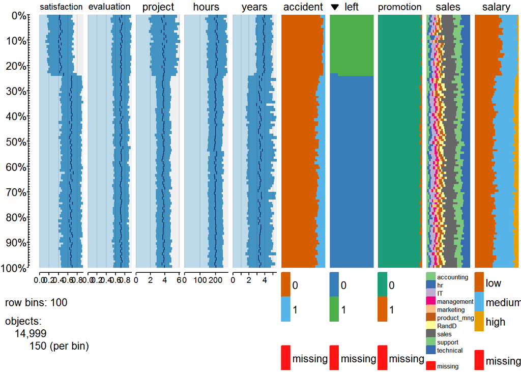

Wile the table plot can show us enough features, We should do some more plots to analyse further

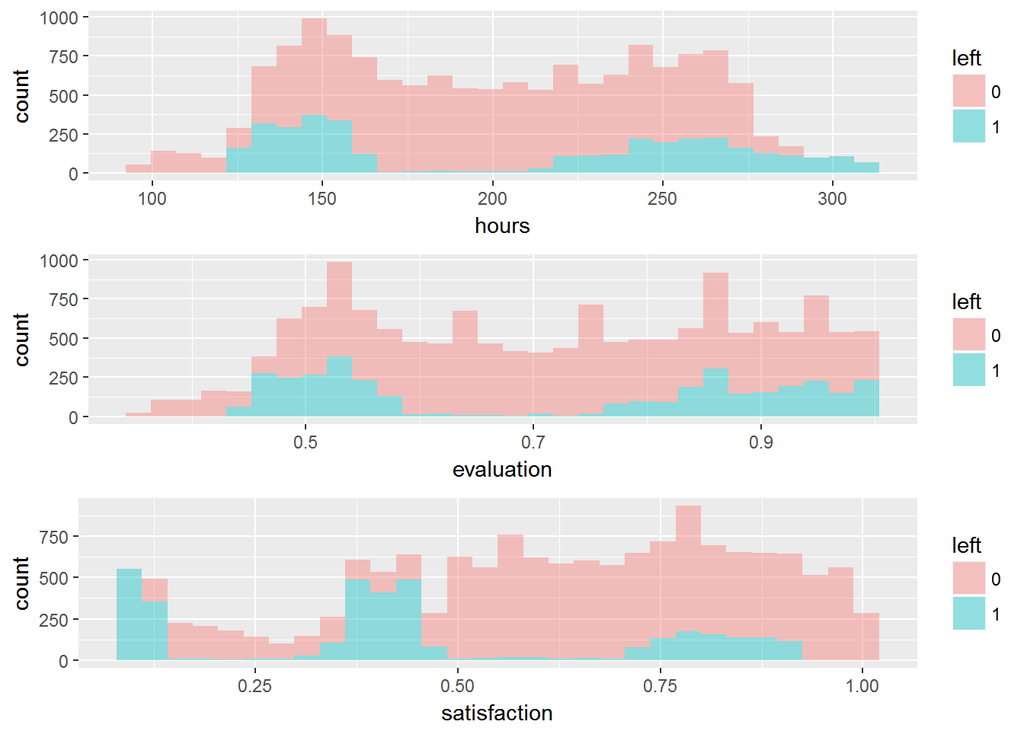

People with too few or too many hours per month on work tend to quit. The former may have little challenge in work and just get bored. On the contrary, the latter dont’t want to spend much time on work. Employees who left get lower or higher last evaluation. Sense of satisfaction seems to be another factor; Satisfation level of 71.32 % employees who left is less than 0.5.

In the former correlation plot, there is a kind of positive correlativity between `project` and `hours`, so the two variables maybe share the similar impact. People with few projets( less than 3) and too many projects( more than 5) tend to leave. In the left group, number of employees with three-year experience is 1586, almost half of the group. But, more than 50% employees with five-year experience quited, which is big loss for a company.

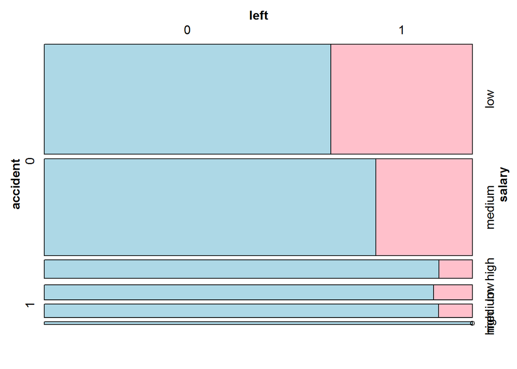

Interestingly, employees with stronger desire to leave tend to have no accident in their work. Low salary also contributes to resigning. Given variable `promotion`, the value’s distribution is so uneven; we can see, only 319 out of 14999 employees have gotten promotion in the last five years. I will just eliminate the variable `promotion` in prediction process.

### Reasons of Employees Leaving?

Here are some reasons I’ve gotten from above analysis:

- Lower satisfication level is significant;
- Few or too many projects, little or too much time on work;
- Low salary;
- Three-to-six year for company is the risk time;
- Few chances to get promotion( I just guess).

### Who Are Valuable Employees And Why Do They Leave?

In my view, the employees with evaluation `>=0.65`, equal or more than 3-year-experience in the company and equal or more than 5 projects in hand can be considered to be experienced and valuable ones for a company. More than half of the experienced ones left. It seems that they suffer from:

- low level of satisfaction
- too much work
- no promotion
- low salary

```
##
##         0         1
## 0.4707379 0.5292621
```

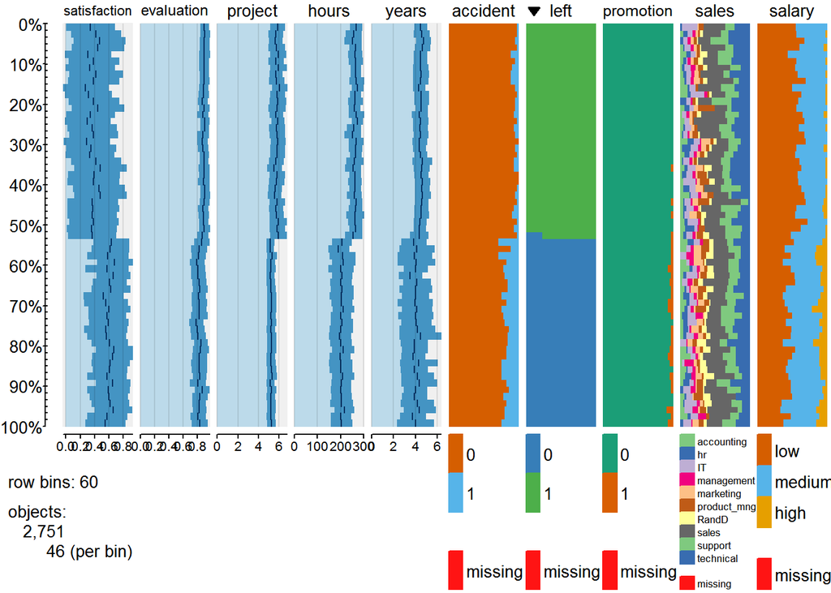

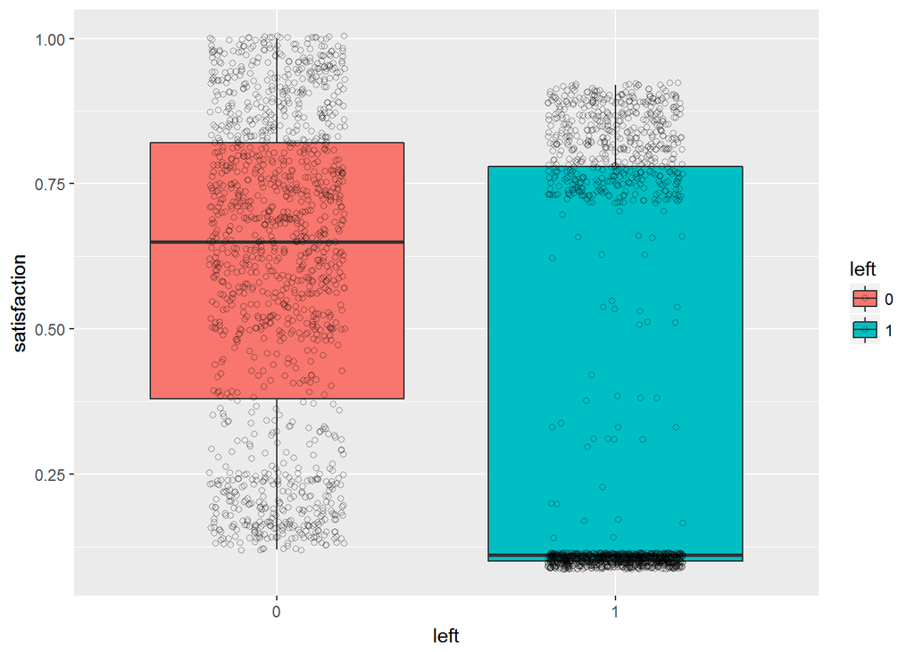

We can find some employees with high sense of satisfaction also left in the box plot. The table plot shows they sustain the same problems with other left ones. Maybe there are still some reasons out of the dataset.

## Step 6: Train And Prediction

It’s time for us to model. We may get a good one to predict who will leave next.We will split the dataset into two parts, `train` and `test`. A classification tree will be built firstly, then forest.

```
## CART
##
## 10000 samples
##     8 predictor
##     2 classes: '0', '1'
##
## No pre-processing
## Resampling: Cross-Validated (5 fold, repeated 3 times)
## Summary of sample sizes: 8000, 8000, 8000, 8000, 8000, 8000, ...
## Resampling results across tuning parameters:
##
##   cp    Accuracy   Kappa
##   0.01  0.9688667  0.9128962
##   0.02  0.9642333  0.9007548
##   0.03  0.9582667  0.8854367
##
## Accuracy was used to select the optimal model using  the largest value.
## The final value used for the model was cp = 0.01.
```

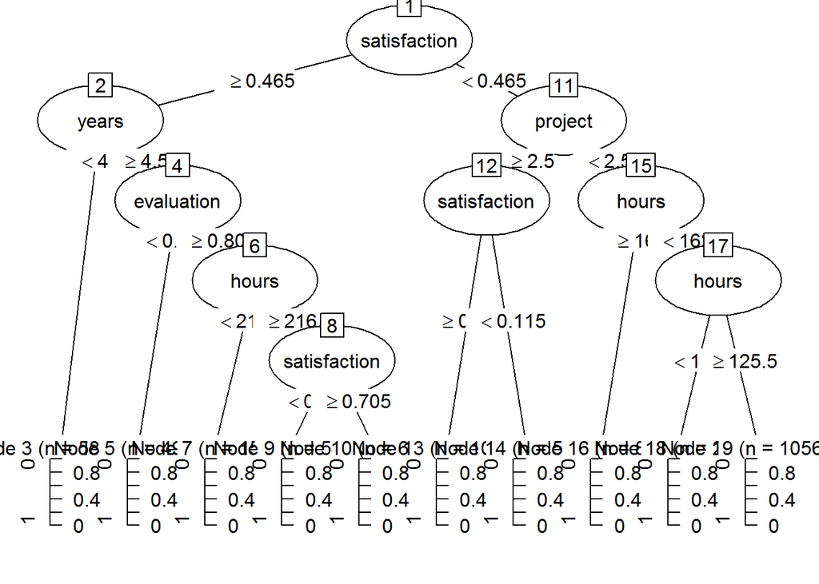

A single tree can get a score like 0.9688667, which is so unbelievable. The original dataset is so friendly. Some variables are more important in prediction as we can see from tree plot, such as, `satisfication`, `years`, `evaluation` and `hours`. Now we model a random forest.

```
## Confusion Matrix and Statistics
##
##           Reference
## Prediction    0    1
##          0 3791   35
##          1   12 1161
##
##                Accuracy : 0.9906
##                  95% CI : (0.9875, 0.9931)
##     No Information Rate : 0.7608
##     P-Value [Acc > NIR] : < 2.2e-16
##
##                   Kappa : 0.974
##  Mcnemar's Test P-Value : 0.001332
##
##             Sensitivity : 0.9968
##             Specificity : 0.9707
##          Pos Pred Value : 0.9909
##          Neg Pred Value : 0.9898
##              Prevalence : 0.7608
##          Detection Rate : 0.7584
##    Detection Prevalence : 0.7654
##       Balanced Accuracy : 0.9838
##
##        'Positive' Class : 0
##
```

So, `rf_mdl` works better, and which variable is the most important? From importance of variables, we can infer reasons that employees left, especially experienced and valuable ones.

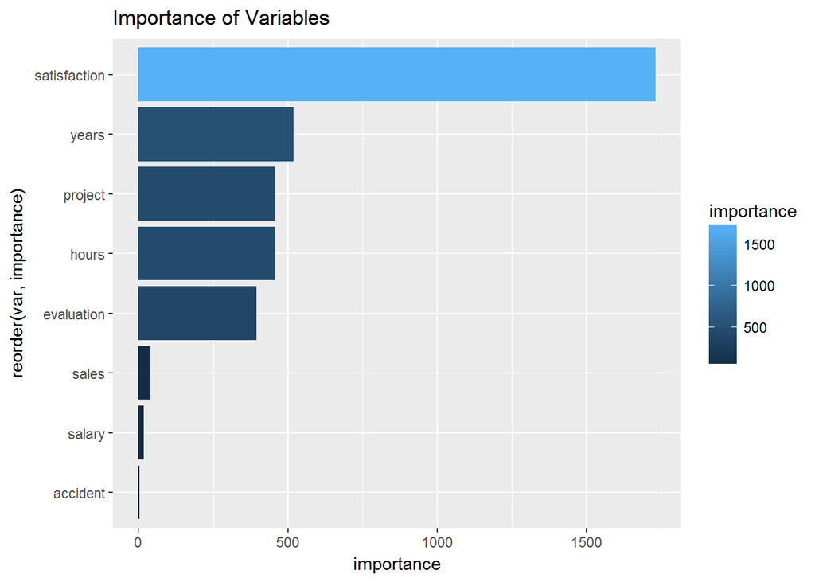

## Step 7: Conclusion

In our opinion Improving level of satisfaction is the key to keep employees remain. While, reasonable workload and working time, promotion and appropriate salary increasing can be useful measures to achieve the key. There is no doubt a valuable employee is important to a company, whether he or she is an experienced or potential one.

https://www.kaggle.com/msjgriffiths/d/ludobenistant/hr-analytics/explore-explain-density-decision-trees